# Lab 1: The R Shakedown

Author

Jesse Brunner

Published

January 11, 2023

## Our goals and rationalle

Much of our work in this class will involve working with data. Whether the raw data from our studies or samples from prior or posterior distributions (trust me, this will make sense), it is all data. Often, however, the data we have access to is not in the format or organized or summarized how we need it. While I assume we have have used R to varying extents, I suspect we have done so in different ecosystems (e.g., base R vs. Tidyverse) and with different tools and workflows. Sometimes we may have even just “borrowed” code that “seemed to work” without really knowing what we were doing.

Given all of this, my goals for this lab are to:

- Develop a common workflow
- Make a habit of knowing what we are doing or working with
- Ensuring we have common tools so we can be on the same page
- Introducing some base R functions we will see used frequently in the text

On this last point, we are going to try to lean on the tools that McElreath uses, that is mostly base R functions, so that we can easily compare our work with his. I tend to use Tidyverse tools, myself, and there will be room for using whatever tools you like once you know what you are doing with them, but there is real value to *knowing* what he is doing in his examples because you are doing the same things.

# Example 1: Small mammals

One of my former students conducted a capture-mark-recapture study at Smoot Hill. You can find the data set [online, here](https://s3.wp.wsu.edu/uploads/sites/1097/2019/08/Eilers.csv). In general, we need to:

1. load the data,
2. check the data,
3. make any adjustments that might be needed[^1],
4. calculate summaries and make plots to ensure we understand what we are dealing with, and
5. re-organize, summarize, or manipulate the data into the format we need, repeating prior steps as needed.

Indeed, this will be our general workflow for dealing with data because it emphasizes knowing what the heck we have at every step of the process. In our specific case, let’s imagine that we want to determine the average and distribution of times captured for each species.

## Load the data

```r
smammals <- read.csv("https://s3.wp.wsu.edu/uploads/sites/1097/2019/08/Eilers.csv")
```

This isn’t always easy, as you likely know. Usually the issues are with formatting and hidden gremlins in Excel.

## Check the data

Let’s take a look at what we just loaded up.

```r
head(smammals)
```

```
  Tag       Date Transect Station Species Sex Age Repro Weight Ear Hindfoot
1  12 06/04/2019    C & D       8    PEMA   M   J    NR   16.5  15       18
2  13 06/04/2019    C & D      16    PEMA   F UNK    NR   22.0  14       19
3  14 06/04/2019    C & D      17    PEMA   M UNK    NR   22.0  13       18
4  15 06/04/2019    C & D      20    PEMA   F UNK    NR   18.0  15       18
5  16 06/04/2019    C & D      25    PEMA   F   A     P   24.0  16       19
6  17 06/04/2019    C & D      35    ZAPR   M UNK    NR   26.0  16       28
  Tail Total Body
1   71    NA   NA
2   80   164   84
3   75   144   69
4   65   139   74
5   85   151   66
6  133   216   83
```

```r
tail(smammals) # always check the bottom, too!
```

```
    Tag       Date Transect Station Species  Sex  Age Repro Weight Ear Hindfoot
312 148 08/04/2019     GRID     100    TAAM <NA> <NA>  <NA>     NA  NA       NA
313  90 08/04/2019     GRID      85    TAAM <NA> <NA>  <NA>     NA  NA       NA
314  92 08/04/2019     GRID      56    TAAM <NA> <NA>  <NA>     NA  NA       NA
315 131 08/04/2019     GRID      52    TAAM <NA> <NA>  <NA>     NA  NA       NA
316 129 08/04/2019     GRID      51    TAAM <NA> <NA>  <NA>     NA  NA       NA
317 130 08/04/2019     GRID      30    TAAM <NA> <NA>  <NA>     NA  NA       NA
    Tail Total Body
312   NA    NA   NA
313   NA    NA   NA
314   NA    NA   NA
315   NA    NA   NA
316   NA    NA   NA
317   NA    NA   NA
```

We can see that each row represents one animal capture.

Now, let’s see how our data are *represented* in R at present.

```r
summary(smammals)
```

```
      Tag             Date             Transect            Station
 Min.   :  3.00   Length:317         Length:317         Min.   :  1.0
 1st Qu.: 43.75   Class :character   Class :character   1st Qu.: 12.0
 Median : 75.00   Mode  :character   Mode  :character   Median : 25.0
 Mean   : 74.67                                         Mean   : 30.8
 3rd Qu.:106.00                                         3rd Qu.: 44.0
 Max.   :153.00                                         Max.   :100.0
 NA's   :1                                              NA's   :1
   Species              Sex                Age               Repro
 Length:317         Length:317         Length:317         Length:317
 Class :character   Class :character   Class :character   Class :character
 Mode  :character   Mode  :character   Mode  :character   Mode  :character




     Weight           Ear           Hindfoot          Tail
 Min.   :11.00   Min.   :11.00   Min.   :17.00   Min.   : 46.00
 1st Qu.:16.00   1st Qu.:14.00   1st Qu.:18.00   1st Qu.: 67.00
 Median :20.50   Median :15.00   Median :18.75   Median : 70.00
 Mean   :26.88   Mean   :14.64   Mean   :19.03   Mean   : 73.24
 3rd Qu.:28.50   3rd Qu.:16.00   3rd Qu.:19.00   3rd Qu.: 76.50
 Max.   :70.00   Max.   :18.00   Max.   :33.00   Max.   :133.00
 NA's   :180     NA's   :261     NA's   :261     NA's   :262
     Total            Body
 Min.   :128.0   Min.   : 65.00
 1st Qu.:144.0   1st Qu.: 75.00
 Median :152.0   Median : 81.00
 Mean   :155.5   Mean   : 81.36
 3rd Qu.:161.5   3rd Qu.: 88.00
 Max.   :216.0   Max.   :100.00
 NA's   :278     NA's   :278
```

```r
str(smammals)
```

```
'data.frame':   317 obs. of  14 variables:
 $ Tag     : int  12 13 14 15 16 17 18 19 20 NA ...
 $ Date    : chr  "06/04/2019" "06/04/2019" "06/04/2019" "06/04/2019" ...
 $ Transect: chr  "C & D" "C & D" "C & D" "C & D" ...
 $ Station : int  8 16 17 20 25 35 41 15 15 16 ...
 $ Species : chr  "PEMA" "PEMA" "PEMA" "PEMA" ...
 $ Sex     : chr  "M" "F" "M" "F" ...
 $ Age     : chr  "J" "UNK" "UNK" "UNK" ...
 $ Repro   : chr  "NR" "NR" "NR" "NR" ...
 $ Weight  : num  16.5 22 22 18 24 26 22 49 58 60 ...
 $ Ear     : int  15 14 13 15 16 16 11 15 NA NA ...
 $ Hindfoot: num  18 19 18 18 19 28 25 33 NA NA ...
 $ Tail    : int  71 80 75 65 85 133 132 95 NA NA ...
 $ Total   : int  NA 164 144 139 151 216 215 NA NA NA ...
 $ Body    : int  NA 84 69 74 66 83 83 NA NA NA ...
```

Nothing seems terribly amiss, yet. In both of these ways we can see that every variable that is not obviously a number is treated as a character. We might want to change that using, for instance, `factor()` or `as.Date()` (or `lubridate::ymd()` in the Tidyverse). Dates are the worst to deal with. Just a heads up that whenever you have dates in Excel you *must* check to see that R has interpreted things correctly. I can’t tell you how often my otherwise perfect code has been foiled by input that wasn’t actually the date I had thought it was. Anyway, for now, we can ignore everything but one: While `Tag`, referring to the ear tag, is really a categorical variable, R thinks it is an integer and will try to do math with it.

## Adjust the variables

Let’s make `Tag` a factor. We really don’t care what about the order, just that they aren’t treated like numbers, so this is easy:

```r
smammals$Tag <- factor(smammals$Tag)
```

And for fun, let’s make `Date` an actual date. The package `lubridate` has some handy functions, but in base R this is:

```r
smammals$Date <- as.Date(smammals$Date, format = "%m/%d/%Y")
```

where `%m` means month numerically (`%b` is the three letter month code), `%d` is the day of the month, and `%Y` is the four digit year (`%y` is the two digit year), while the slashes in between represent the actual dividers between date components. Be sure to check the formatting of these variables to ensure this stuff worked!

## Look at summaries and plots to understand data

We have already checked the distributions of the values of lengths and weights using the `summary()` function, but we should still plot our data to make sure that combinations of variables make sense. Trust me, things get shifted, relationships are the opposite of what you expect, and other gremlins exist. If you don’t check, you won’t know there is a problem until it is too late!

Let’s simply plot weight by body length for each species to make sure these variables generally go up together as expected.

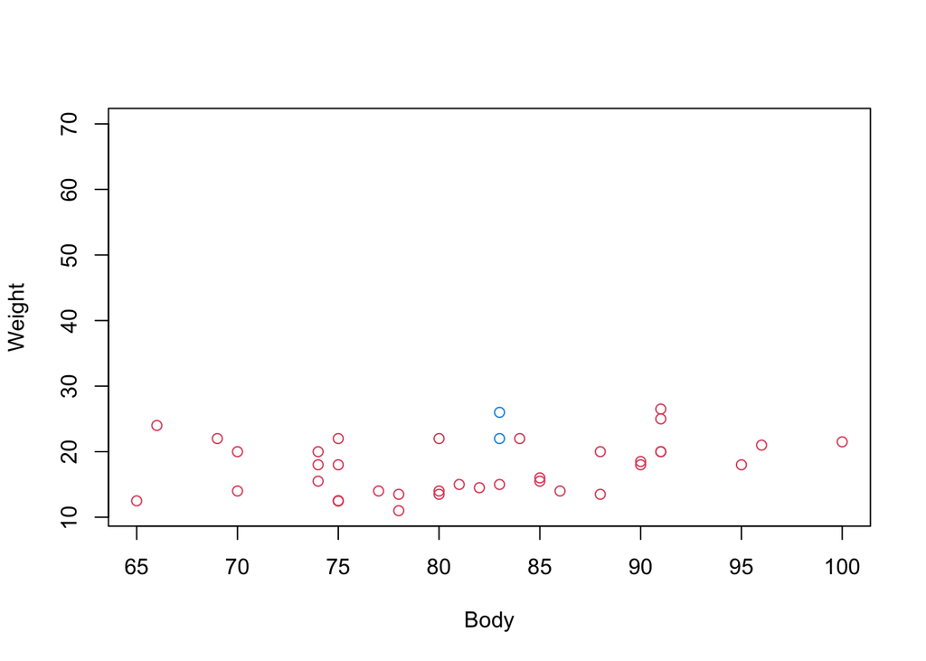

```r
plot(Weight ~ Body, col = factor(Species), data = smammals)
```

Full disclosure, I hate plotting in base R anymore! I can’t even figure out how to add a meaningful legend anymore. This is much simpler with `ggplot2`, if you know how that works:

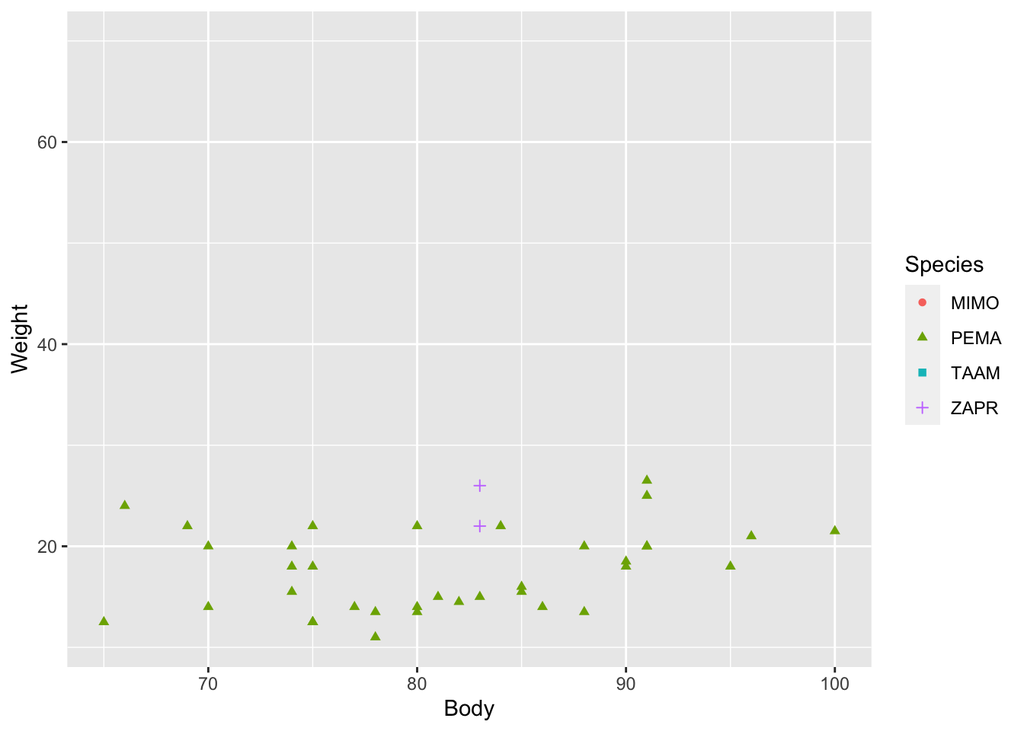

```r
library(ggplot2)
ggplot(data=smammals,
       aes(x=Body, y = Weight,
           color = Species, shape = Species)) +
  geom_point()
```

I’m fine with you using whatever plotting functions you use. (McElreath often uses his own because why not?)

Anyway, we are starting to see some issues showing up in both graphs. First, it looks like only PEMA and two ZAPR are showing up on both plots. Is that right? Second, why does the y-axis go all the way to 70 when the largest weight seems to be about 30? Indeed, if we look at our summaries from above, the maximum weight is 70, so why isn’t this plotting? Time for some data inspection!

```r
summary(smammals[smammals$Species == "TAAM", ])
```

```
      Tag          Date              Transect            Station
 90     : 6   Min.   :2019-06-04   Length:92          Min.   :  1.00
 19     : 3   1st Qu.:2019-07-03   Class :character   1st Qu.: 13.00
 20     : 3   Median :2019-07-13   Mode  :character   Median : 37.00
 76     : 3   Mean   :2019-07-13                      Mean   : 39.26
 89     : 3   3rd Qu.:2019-07-30                      3rd Qu.: 57.00
 (Other):73   Max.   :2019-08-04                      Max.   :100.00
 NA's   : 1                                           NA's   :1
   Species              Sex                Age               Repro
 Length:92          Length:92          Length:92          Length:92
 Class :character   Class :character   Class :character   Class :character
 Mode  :character   Mode  :character   Mode  :character   Mode  :character




     Weight           Ear        Hindfoot       Tail        Total
 Min.   :18.00   Min.   :15   Min.   :33   Min.   :95   Min.   : NA
 1st Qu.:48.25   1st Qu.:15   1st Qu.:33   1st Qu.:95   1st Qu.: NA
 Median :51.00   Median :15   Median :33   Median :95   Median : NA
 Mean   :51.54   Mean   :15   Mean   :33   Mean   :95   Mean   :NaN
 3rd Qu.:56.25   3rd Qu.:15   3rd Qu.:33   3rd Qu.:95   3rd Qu.: NA
 Max.   :70.00   Max.   :15   Max.   :33   Max.   :95   Max.   : NA
 NA's   :58      NA's   :91   NA's   :91   NA's   :91   NA's   :92
      Body
 Min.   : NA
 1st Qu.: NA
 Median : NA
 Mean   :NaN
 3rd Qu.: NA
 Max.   : NA
 NA's   :92
```

First, be sure you understood what’s happening here (i.e., how I’m subsetting the `smammals` data set by those where the condition is true and then getting a summary of this reduced data set). (And yes, this would be much easier to follow in the Tidyverse! But not all things are.)

We could also use the `tapply()` function:

```r
tapply(X = smammals$Body,
       INDEX = smammals$Species,
       FUN = summary)
```

```
$MIMO
   Min. 1st Qu.  Median    Mean 3rd Qu.    Max.    NA's
     NA      NA      NA     NaN      NA      NA       1

$PEMA
   Min. 1st Qu.  Median    Mean 3rd Qu.    Max.    NA's
  65.00   75.00   80.00   81.27   88.00  100.00     183

$TAAM
   Min. 1st Qu.  Median    Mean 3rd Qu.    Max.    NA's
     NA      NA      NA     NaN      NA      NA      92

$ZAPR
   Min. 1st Qu.  Median    Mean 3rd Qu.    Max.    NA's
     83      83      83      83      83      83       2
```

I like to think of this function as the “table” apply function because it first organizes our data like a data table, according to whatever index we’ve given it, and then applies the function of our choice. Or, more specifically, it applies the function specified by `FUN` to the vector (or similar) of data specified by `X`, which is split into groups according to the variable specified by `INDEX`. We will see and use several `apply` functions in this class (mostly `apply()`, which we will see below, and `sapply()`). They are *not* always very intuitive, but they are very powerful and McElreath uses them frequently, so it behooves us to get used to them. (Also note, in this case it would be easy to accomplish the same thing in the Tidyverse, but there are several cases we’ll see where it is *not* easy or transparent to do so.)

Anyway, we can see that we were missing data on `Body` length for all but PEMA and ZAPR, hence why they didn’t show up. Since we’re not really interested in this, we can move on, but it does highlight why *looking* at your data is important.